# Twitter Mining Project

The purpose of this project is to perform an analysis of tweets. The tweets were mined with R from twitter.

The first step towards a tweet analysis is loading the required libraries.

Then we set up a connection to Twitter by providing the consumer_key, consumer_secret, access_token and access_token_secret that we have got from twitter.

```r
setup_twitter_oauth(consumer_key, consumer_secret, access_token, access_token_secret)
```

```
## [1] "Using direct authentication"
```

With the availableTrendLocations() function we can see all the areas worldwide that we can get trends from.

```r
trend <- availableTrendLocations()
head(trend)
```

```
##        name country woeid
## 1 Worldwide             1
## 2  Winnipeg  Canada  2972
## 3    Ottawa  Canada  3369
## 4    Quebec  Canada  3444
## 5  Montreal  Canada  3534
## 6   Toronto  Canada  4118
```

```r
trend
```

[output not shown]

[output cut: 453 more lines]

More specifically, by calling the trend function, we see that Thessaloniki,Greece has the code 963291 and if we apply that code to getTrends() function we will get the leading trends on Twitter for the area of Thessaloniki Greece.

```r
thess <- getTrends(963291)
thess
```

[output not shown]

[output cut: 117 more lines]

```r
thess$name
```

[output not shown]

# Searching the Twitter.

searchTwitter() function will mine the tweets for us. In this case we are searching Twitter for the topic “morning+coffee” and we ask searchTwitter() function to bring us the 500 most recent tweets written in English. The output of this function is a list.

```r
tweets <- searchTwitter("morning+coffee", n = 500 , lang = "en" , resultType = "recent")
class(tweets)
```

```
## [1] "list"
```

with the following function we transform the tweets list to a character vector.

```r
tweets_text <- sapply(tweets, function(x) x$getText())
class(tweets_text)
```

```
## [1] "character"
```

Then with the use of tm package we transform the character vector we created above to a Corpus that will help us perform our analysis.

```r
tweet_corpus <- Corpus(VectorSource(tweets_text))
tweet_corpus
```

```
## <<VCorpus>>
## Metadata:  corpus specific: 0, document level (indexed): 0
## Content:  documents: 500
```

# Cleaning data.

The next step in the process is to remove any unwanted terms and character. In this particular case we use tm_map() function 6 times and we do the following: a) remove any non-english word and characters. b) make all characters lowercase. c) remove commonly used words with stopwords function. d) remove any white space. e) remove urls and f) remove numbers.

```r
removeNumPunct <- function(x) gsub("[^[:alpha:][:space:]]*", "", x)
tweet_corpus_clean <- tm_map(tweet_corpus, content_transformer(removeNumPunct))
tweet_corpus_clean <- tm_map(tweet_corpus_clean, content_transformer(tolower))
tweet_corpus_clean <- tm_map(tweet_corpus_clean, removeWords, stopwords("en"))
tweet_corpus_clean <- tm_map(tweet_corpus_clean, stripWhitespace)
removeURL <- function(x) gsub("http[^[:space:]]*", "", x)
tweet_corpus_clean <- tm_map(tweet_corpus_clean, content_transformer(removeURL))
tweet_corpus_clean <- tm_map(tweet_corpus_clean, removeNumbers)
```

# WordClouds

After having removed all of the above we can use the wordcloud() function from tm package in order to create the wordcloud. Below there are two wordclouds, the first one is simply a function call on the clean corpus, and the second one has more parameters in it, for example we have deactivated the random.order function by setting it to FALSE, we have set a limit of 500 to the number of words that will appear in the wordcloud, we have the range of the character scale between 3 and 0.5 and finally we have set the colors parameter to “rainbow(50)” which means that we want to use 50 colors of the rainbow as color for the wordcloud.

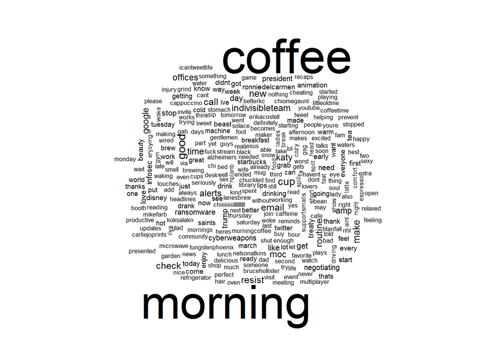

```r
wordcloud(tweet_corpus_clean)
```

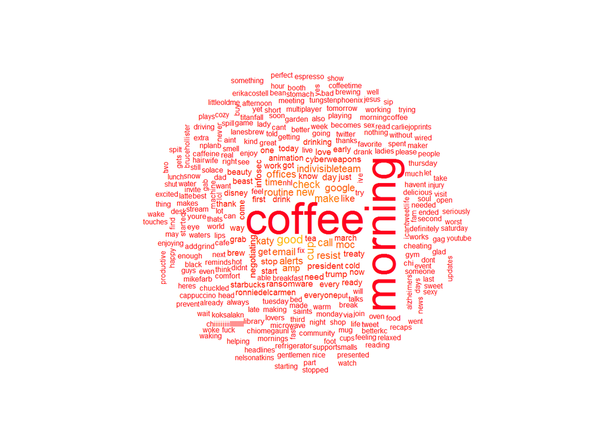

```r
wordcloud(tweet_corpus_clean, random.order = F, max.words = 500, scale = c(3,0.5), colors = rainbow(50))
```

# Building a Term Document Matrix

Following up the plotting of the wordcloud, we want to find the most frequent terms of the dataset. In order to do so, we have to transform the Corpus we created above to a Term Document Matrix by calling the TermDocumentMatrix function. Then we transform the Term Document Matrix created to a simple matrix and sort it in decreasing order.Finally, we build a data frame that will include all words and their frequency. By calling the head() and tail() functions we can see the 20 most and least frequent terms.

```r
tdm <- TermDocumentMatrix(tweet_corpus_clean)
m <- as.matrix(tdm)
v <- sort(rowSums(m),decreasing=TRUE)
d <- data.frame(word = names(v),freq=v)
head(d, 20)
```

```
##                            word freq
## coffee                   coffee  484
## morning                 morning  476
## good                       good   62
## cup                         cup   53
## make                       make   44
## new                         new   44
## call                       call   40
## check                     check   40
## routine                 routine   38
## email                     email   37
## resist                   resist   37
## alerts                   alerts   36
## google                   google   36
## indivisibleteam indivisibleteam   36
## katy                       katy   36
## moc                         moc   36
## offices                 offices   36
## time                       time   33
## amp                         amp   32
## like                       like   28
```

```r
tail(d, 20)
```

```
##                    word freq
## wipe               wipe    1
## wisconsin     wisconsin    1
## woah               woah    1
## women             women    1
## won                 won    1
## workout         workout    1
## wrapped         wrapped    1
## wrestling     wrestling    1
## xseedgames   xseedgames    1
## yakreloaded yakreloaded    1
## year               year    1
## yelled           yelled    1
## yep                 yep    1
## yetis             yetis    1
## youwantsome youwantsome    1
## yum                 yum    1
## yup                 yup    1
## zach               zach    1
## zhanna           zhanna    1
## zoeseely       zoeseely    1
```

# PLOTS

1. Barplot of frequent words. Using barplot we can plot the 10 most frequent terms.

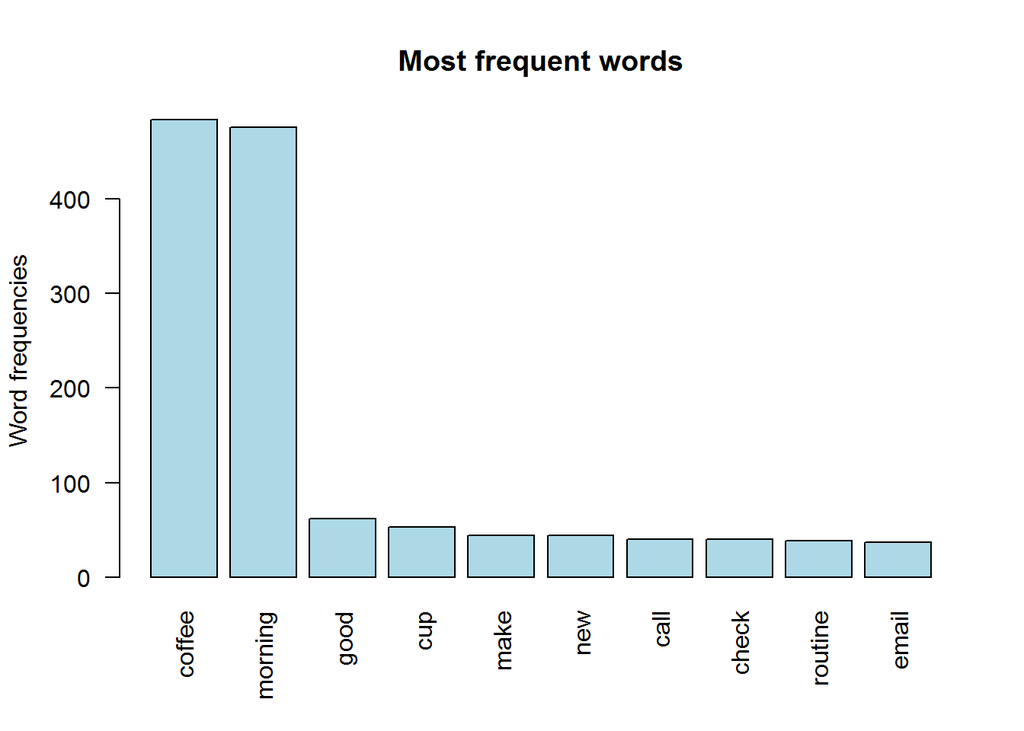

```r
barplot(d[1:10,]$freq, las = 2, names.arg = d[1:10,]$word,
        col ="lightblue", main ="Most frequent words",
        ylab = "Word frequencies")
```